# MATP-4910 COVID-Twitter Final Project Notebook

Thomas Shweh

December 2020

# 1 Final Project: Submission Links

*This should be the first section of your final project notebook. Fill out the following according to how you submitted your notebook!*

- github repository: https://github.com/TheRensselaerIDEA/COVID-Twitter
- Your github ID: shwehtom89
- Github branch name of your submitted notebook: darl-shweht-07Dec2020
- link to knitted, merged notebook (post to LMS!):
  - https://htmlpreview.github.io/?https://github.com/TheRensselaerIDEA/COVID-Twitter/blob/darl-shweht-07Dec2020/DARL-2020-Notebooks/darl_shweht_07Dec2020.html

# 2 Overview & Problems Tackled

Every message posted by public leaders is subject to a wide range of public discourse and opinion. In times of a pandemic, the messages of leaders, posted in avenues with near instant feed like Twitter can have immediate effects on the public and generate unknown reactions. As such, a tool that could generate a response distribution and predict public preception to issues to a message or theme might be in the interest of leaders and official organizations. Just as the Covid Twitter project previously studied discourse themes and topics related to mask-wearing, this project aims to move in the direction of generating a distribution of responses and their perception to a single message. [1]

This is where Sentiment comes into the picture. In order to generate how the public will respond to a Tweet, a distribution of responses will be generated using DialoGPT and each of these responses will be scored on based on their sentiment. The aggregate of these scores will represent how the public Twittersphere will respond to a Tweet. Currently the COVID Twitter analysis pipeline uses VADER Sentiment analysis in order to generate a sentiment score for a particular tweet. While VADER sentiment provided a baseline to evaluate sentiment, it has it’s shortcoming when evaluating the sentiment of Tweets. [2] VADER is based on a pre-scored and lexicon and sentiment is calculated by taking an aggregate of these scores. The limitations come from when the model encounters words outside its lexicon and nuance phrases within tweets which produce mixed results from the model. A prime example can be found below.

[figure not shown]

In this example we can see that VADER does not know how to interpret this Tweet and gives it a neutral score. However, we can see that VADER cannot interpret the hashtag #wewillgetthroughthis which is seen as a positive message.

Hence, the central question if this notebook arises. Can we create a classification model that can classify Tweet sentiment that is more robus contextually aware?

Enter BERT, a deep learning language model released by Google in 2018 that can be finetuned to solve a variety of Natural Language Processing tasks. The main difference with BERT lies in its encoding mechanism and its transformer architecture. Traditioanlly, language models are interpreted in one direction, whereas in BERT, the whole “sentence” itself is encoded which leads to a more contextually aware language model. Another benefit of using BERT is its architecture. The base model is pretrained on a large corpus of text which alleviates the need of expensive computaion to train a model to solve a different model. Hence, we can finetune the base model to solve a classification problem of scoring Tweet Sentiment. This notebook will explore training a BERT Model to classify Tweet Sentiment. Specifically CT-BERT will be used as it is trained on a corpus of Tweets during the coronavirus pandemic

# 3 Data Description

In order to train the model, we will need a large dataset of Tweets with labeled sentiment. Fortunately there exists a dataset of labeled Tweets hosted under SemEval. SemEval is a competition in computational linguistics that happened yearly from 2013-2017 for Tweet Sentiment classfication. The dataset can be found on https://www.dropbox.com/s/byzr8yoda6bua1b/2017_English_final.zip

```python
import numpy as np
import pandas as pd
import seaborn as sns
import requests
import os.path
from sklearn.model_selection import train_test_split

def downloadDataset(fileurl: str, outpath: str='semeval.zip'):
    if '.zip' not in outpath:
        outpath = f'{outpath}.zip'

    if not os.path.isfile(outpath):
      res = requests.get(fileurl, allow_redirects=True)
      with open(outpath, "wb") as f:
          f.write(res.content)
```

The data varries from year to year so some data cleanup was necessary in order to create a uniform dataset for training. Since the goal of this project is not to solve the subtasks in the SemEval dataset, all the labeled data will be aggregated into one big dataset. Specifically one task had 5 classes of labeled sentiment and that was normalized into 3 different classes so it could be better aligned without our dataset. Below is some parsing needed in order to aggregate the dataset into TweetId, Tweet, Sentiment columns

```python
# Create a generator for SemEval Twitter Data
# The data files are separated by tab and each folder has it's own data format

def parseTwitter(folders):
  mapping = {'-2': 'negative', '-1': 'negative', '0': 'neutral', '1': 'positive', '2': 'positive'}

  for folder in folders:
    for file in [f'{folder}/{f}' for f in os.listdir(folder) if 'twitter' in f]:
      with open(file, 'r') as f:
        for line in f:
          segments = line.rstrip().split('\t')
          if len(segments) < 3:
            continue
          elif 'A' in folder:
            tweet_data = [segments[0], segments[1], ''.join(segments[2:])]
          elif 'B' in folder:
            tweet_data = [segments[0], segments[-2], segments[-1]]
          else:
            tweet_data = [segments[0], mapping[segments[-2]], segments[-1]]
          yield tweet_data

def loadData(datapath: str='semeval'):
    # unzip data if folder is not present
    if not os.path.isdir(datapath):
      import zipfile
      with zipfile.ZipFile(f'{datapath}.zip', 'r') as zip_ref:
          zip_ref.extractall(datapath)

    # get all folders with relavent data in them
    task_folders = [f'{datapath}/2017_English_final/GOLD/{folder}'
                    for folder in os.listdir(f'{datapath}/2017_English_final/GOLD')
                    if os.path.isdir(f'{datapath}/2017_English_final/GOLD/{folder}')
    ]

    # create a pandas dataframe
    return pd.DataFrame(parseTwitter(task_folders), columns=['TweetId', 'Sentiment', 'Text'])


downloadDataset("https://www.dropbox.com/s/byzr8yoda6bua1b/2017_English_final.zip?dl=1")
df = loadData()
```

Below is the result of out data aggregation. There exists an “off topic” sentiment class. This was discarded since it only was comprised of 3 tweets.

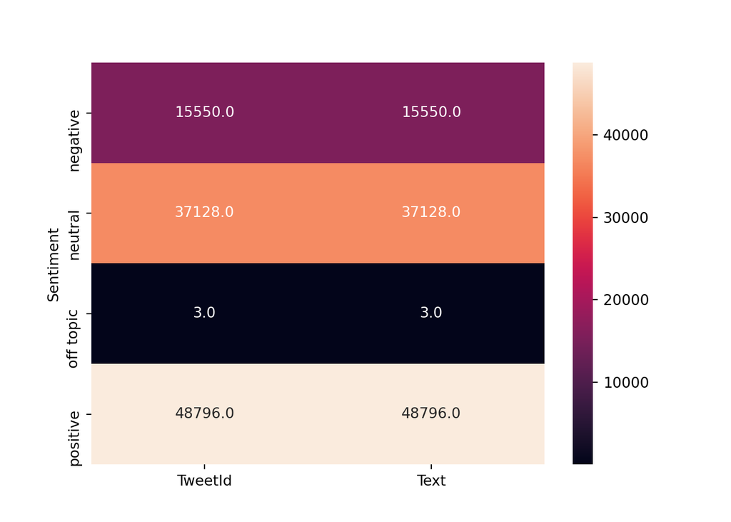

```python
sns.heatmap(df.groupby(['Sentiment']).agg('count'), annot=True, fmt=".1f")
```

Here is a preview of of the tweets in this dataset

```python
df.head()
```

```
##               TweetId  ...                                               Text
## 0  681563394940473347  ...  @MargaretsBelly Amy Schumer is the stereotypic...
## 1  675847244747177984  ...  @dani_pitter I mean I get the hype around JLaw...
## 2  672827854279843840  ...  Amy Schumer at the #GQmenoftheyear2015 party i...
## 3  671502639671042048  ...  "Amy Schumer may have brought us Trainwreck, b...
## 4  677359143108214784  ...  I just think that sports are stupid &amp;anyon...
##
## [5 rows x 3 columns]
```

For this project dataset was split using scikit learn with a constant seed into 70% training, 15% testing, 15% validation sets.

```python
df = df[df.Sentiment != 'off topic']
df.Sentiment = pd.Categorical(df.Sentiment)
df.Sentiment = df.Sentiment.map({'negative': 0, 'neutral': 1, 'positive':2})

train_text, temp_text, train_labels, temp_labels = train_test_split(df['Text'], df['Sentiment'],
                                                                    random_state=2018,
                                                                    test_size=0.3,
                                                                    stratify=df['Sentiment'])

val_text, test_text, val_labels, test_labels = train_test_split(temp_text, temp_labels,
                                                                random_state=2018,
                                                                test_size=0.5,
                                                                stratify=temp_labels)
```